# SDGB-7844 Homework #4: Probability Distributions

## The Exponential Probability Distribution & Central Limit Theorem

The magnitude of earthquakes in North America can be modeled as having an exponential distribution with mean $\mu$ of 2.4.

For an *exponential distribution*:

**Mean:** $\mathbb{E}[X] = {\lambda}$

**Variance:** $\mathbb{E}[X^2] - (\mathbb{E}[X])^2 = \lambda^2$

18. Simulate 1000 earthquakes and plot the distribution of Richter Scale values (Hint: `rexp(x, rate = 1/lambda)`). Let this data represent $X$. Create a histogram of $X$ and describe the shape of this distribution. How does this differ from the normal distribution?

This distribution has a higher density of the data closer to 0 rather than the mean like in the normal distribution

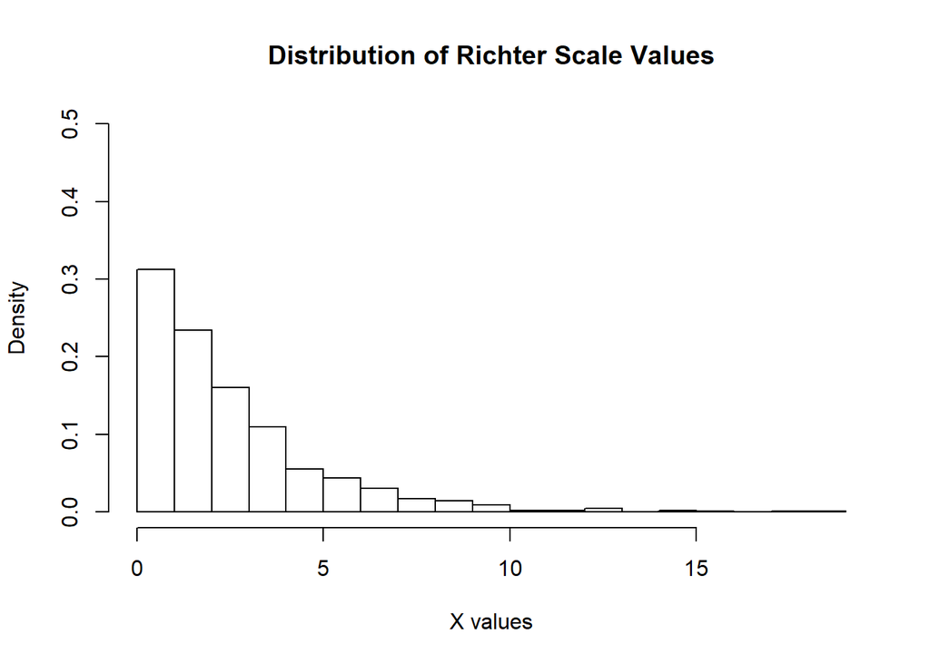

```r
#Simulate the data
data_18 <- rexp(1000, 1/2.4)

#Create the graph
hist(data_18, prob = TRUE, ylim = c(0, 0.5), breaks = 20, main = "Distribution of Richter Scale Values", xlab = "X values")
```

19. Find the probability that an earthquake occurring in North America will fall between 2 and 4 on the Richter Scale.

```r
#Getting the higher and lower value to calculate the between 2-4
lower_data <- pexp(2, 1/2.4)
higher_data <- pexp(4, 1/2.4, lower.tail = FALSE)
result_19 <- 1 - lower_data - higher_data

result_19
```

```
## [1] 0.2457226
```

20. How rare is an earthquake with a Richter Scale value of greater than 9?

```r
pexp(9, 1/2.4, lower.tail = FALSE)
```

```
## [1] 0.02351775
```

21. Create a function which will simulate multiple samples drawn from an exponential distribution with $\lambda$ = 2.4 (Hint: `rexp(x, rate = 1/lambda)` and return a vector containing the mean values for each of your samples. Your arguments should be lamba, simulations for the number of simulations per sample, and n (sample size) for the number of samples of size simulations to be created.

```r
richter_scale <- function(lambda, simulations, n) {
  array_21 <- c()
  for (i in 1:n) {
    #Simulating the data
    data_21 <- rexp(simulations, 1/lambda)

    #Get the mean
    data_21_mean <- mean(data_21)

    #Append the vector which will be returned with the mean data
    array_21 <- append(array_21, data_21_mean)
  }
  return(array_21)
}
```

22. Use your function with arguments `lambda` = 2.4, `simulations` = 1000, `n` = 40 to create a vector of sample mean values of Richter Scale readings. Let $\bar{X}$ represent this data. Plot a histogram of the data. Describe the distribution of $\bar{X}$. Is $\bar{X}$ distributed differently than $X$?

Since each data point in this histogram is the mean of all the simulations, X-bar is more resembled of a normal distribution, which it should be since this type of means should be normally distributed.

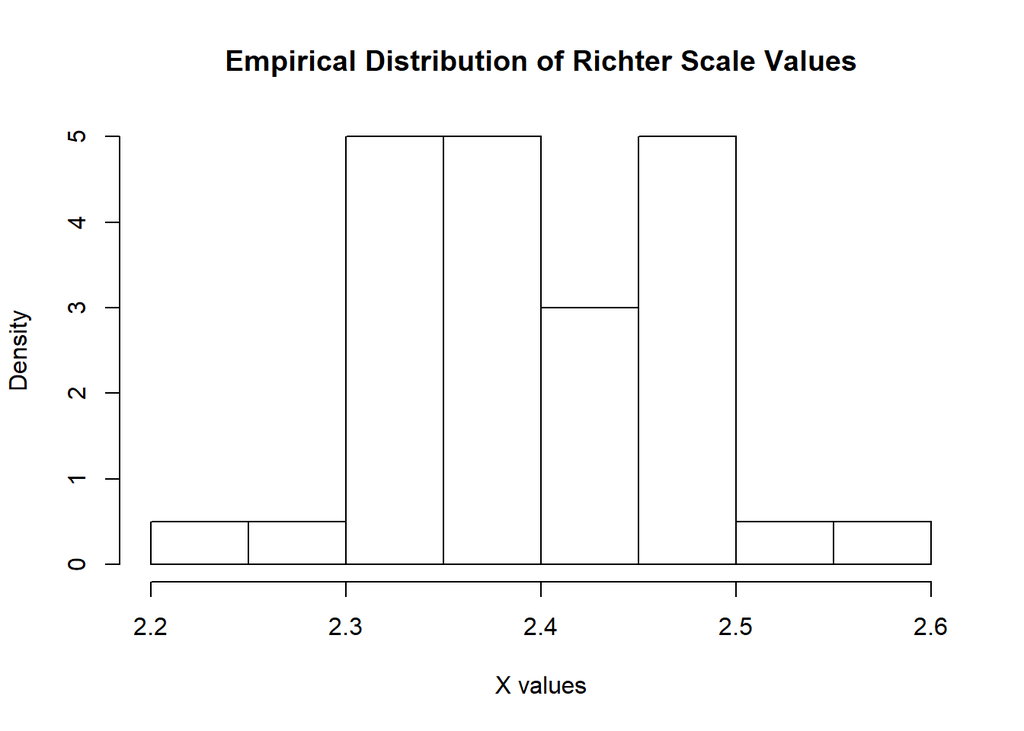

```r
x_bar_22 <- richter_scale(2.4,1000,40)
hist(x_bar_22, prob = TRUE, main = "Empirical Distribution of Richter Scale Values", xlab = "X values")
```

23. Calculate the sample mean and sample variance for the data simulated in #18. Calculate the population variance given $\lambda$ = 2.4.

```r
mean_23 <- mean(data_18)
svariance_23 <- var(data_18)
pvariance_23 <- mean((data_18 - 2.4)^2)

print(paste("Sample mean:", toString(mean_23)))
```

```
## [1] "Sample mean: 2.46332391808791"
```

```r
print(paste("Sample variance:", toString(svariance_23)))
```

```
## [1] "Sample variance: 5.97450211128273"
```

```r
print(paste("Population variance:", toString(pvariance_23)))
```

```
## [1] "Population variance: 5.97253752777346"
```

24. Create a plot of $\bar{X}$. Make sure to set `prob=TRUE` in the `hist()` function. Include vertical lines for the sample and theoretical mean values (red = sample mean, blue = theoretical mean).

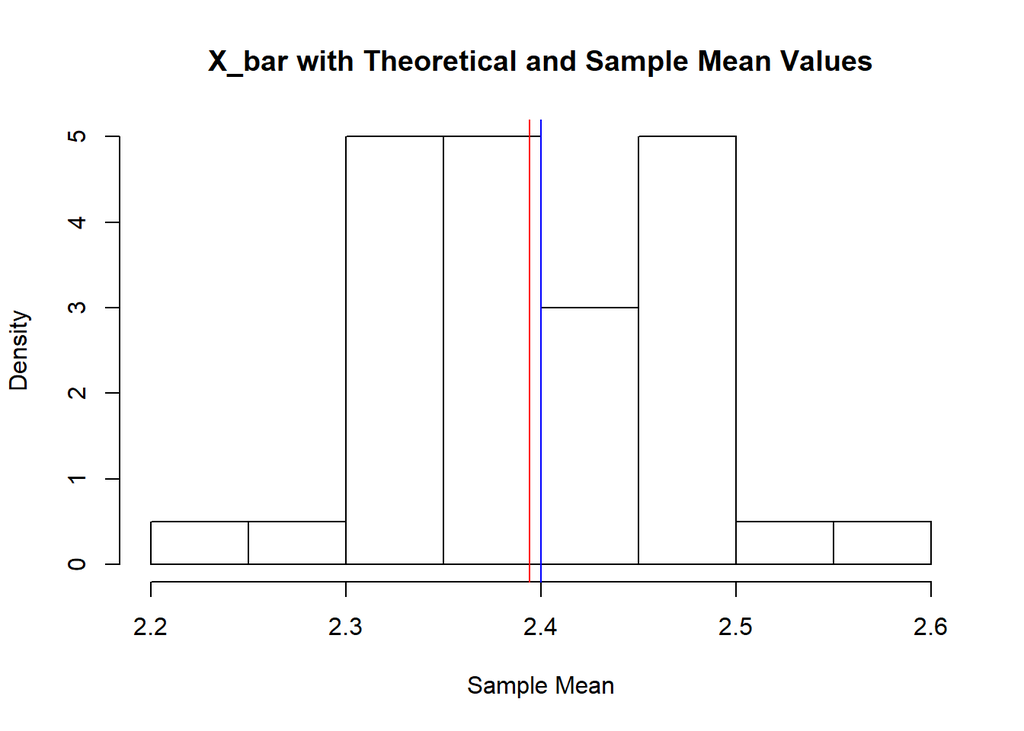

```r
hist(x_bar_22, prob = TRUE, main = "X_bar with Theoretical and Sample Mean Values", xlab = "Sample Mean")
abline(v = c(mean(x_bar_22), 2.4), col = c("red", "blue"))
```

25. Add lines to our plot of $\bar{X}$ to plot the density for both our simulated sample and theoretical population (Hint: use `dnorm(x, mean=lambda, sd=(lambda/sqrt(n))` to calculate theorical population density). Make sure to set `prob=TRUE` in the `hist()` function.

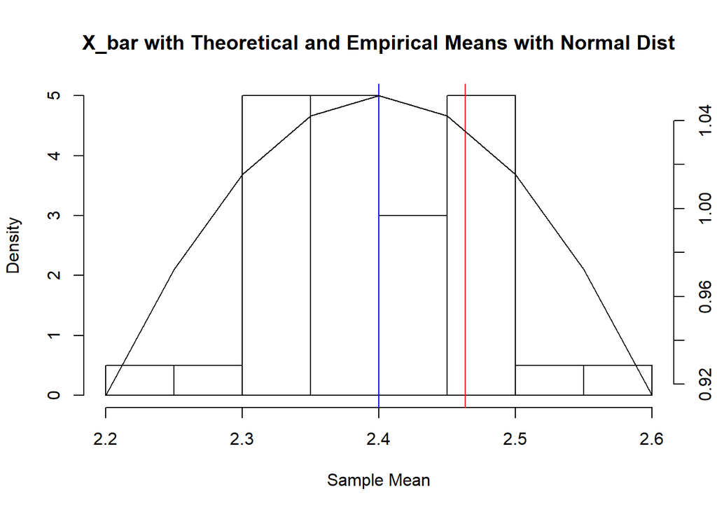

```r
x_25 <- seq(2.2, 2.6, by = 0.05)
theo_pop_den <- dnorm(x_25, mean = 2.4, sd = (2.4/sqrt(40)))
hist(x_bar_22, prob = TRUE, main = "X_bar with Theoretical and Empirical Means with Normal Dist", xlab = "Sample Mean")
abline(v = c(mean(data_18), 2.4), col = c("red", "blue"))
par(new = TRUE)
plot(theo_pop_den, type = "l", axes = FALSE, xlab = "", ylab = "")
axis(side = 4)
```

26. The Central Limit Theorem states that if you take many repeated samples from a population, and calculate the averages or sum of each one, the collection of those averages will be normally distributed. Does the shape of the distribution of $X$ matter with respect to the distribution of $\bar{X}$? Is this true for all **any** parent distribution of $\bar{X}$?

The shape of the distribution of X will not impact whether or not X_bar is normally distributed or not. What X can impact is the how fat the tails are and other differences in characteristics which can be found in other normal distributions. This should be true for any parent distribution since X_bar is means of different simulations, and their results will always fall in a normal distribution, it does not matter whether it is a geometric, exponential, or binomial.

27. What will happen to the distribution of $\bar{X}$ if you re-run your function with arguments `lambda` = 2.4, `simulations` = 10000, `n` = 40? How does the variance of $\bar{X}$ change from our data simulated for $\bar{X}$ in #25? Create a figure with the histograms (`prob=TRUE`) for both of our $\bar{X}$ sampling distributions. Explain the difference in the two distributions of $\bar{X}$ (simulations = 1000, simulations = 10000).